# Analysis of Covid and related policy data in the United States

## 1 introduction

It is the end of 2021, but unfortunately the pandemic of COVID-19 has not yet ended. Even worse, the virus is still mutating and spreading. Especially, the Omicron mutaion is discovered and the virus could spread faster than ever. The vaccine is not that effective for the Omicron mutation. In this situation, personal effort is not enough to prevent the virus from spreading. Impact of governments is strongly needed to control the pandemic. In this tutorial, I will analyze the data of the government policies and the data of the COVID-19. I will try to answer the following questions:

1. How to define strigency of the policies?
2. How the strigenties of the policies are related to the COVID-19?
3. How to visualize the data to show the relationship between the policies and the COVID-19?

## 2 Data collection and description

I collect all the data from the following github reposities or links. All the data I used was updated in Dec 11th, 2021.

#### 2.1 Vaccinations data:

Vaccinations data is from the CDC, [COVID-19 Vaccinations in the United States,County](https://data.cdc.gov/Vaccinations/COVID-19-Vaccinations-in-the-United-States-County/8xkx-amqh). From this dataset we can know the number of people from each county who have been vaccinated for the COVID-19. The data includes vaccination date, recipents state and county, and number of people who have been fully vaccinated, etc.. The format of date is MM/DD/YYYY.

#### 2.2 Policy and covid data:

Policy data is from covid-policy-tracker. Some basic information about COVID-19 like total cases and deaths are embeded in this dataset (Covid data is from [COVID-19 Data Repository by the Center for Systems Science and Engineering (CSSE) at Johns Hopkins UniversityJohns Hopkins University Center for Systems Science and Engineering (JHU CSSE)](https://github.com/CSSEGISandData/COVID-19) ). In this dataset it defines strigency $SI=\frac{1}{9}(\sum\limits_{j=1}^{8}{Cj}+H1)$. From $C1$ to $C8$, the meaning of each number is as follows:

| ID | Description |
| --- | --- |
| $C1$ | Record closings of schools and universitiesTotal cases |
| $C2$ | Record closings of workplaces |
| $C3$ | Record cancelling public events |
| $C4$ | Record limits on gatherings |
| $C5$ | Record closing of public transport |
| $C6$ | Record orders to "shelter-in-place" and otherwise confine to the home |
| $C7$ | Record restrictions on internal movement between cities/regions |
| $C8$ | Record restrictions on international travel |
| $H1$ | Record restrictions on gatherings |

For more details about the data, please refer to the [codebook](https://github.com/OxCGRT/covid-policy-tracker/blob/master/documentation/codebook.md).

#### 2.3 timeline:

I get information about the timeline from [CDC](https://www.cdc.gov/museum/timeline/covid19.html). The timeline is from Dec 12, 2019 to Apr 23, 2021. By this data, I can roughly know what happened during the pandemic. It may provide some useful information to understand how Covid and policies are impacted by each other.

```python
import pandas as pd
import numpy as np
import contextily as cx
import requests
from bs4 import BeautifulSoup as bs
from matplotlib import pyplot as plt
import pandas_alive
import geopandas
import warnings
warnings.filterwarnings('ignore')
# read data
vaccine_data = pd.read_csv('covid/COVID-19_Vaccinations_in_the_United_States_County.csv')
vaccine_data = vaccine_data[['Date','Recip_State','Series_Complete_Yes']]

covid_data_US = pd.read_csv('covid/COVID-19/csse_covid_19_data/csse_covid_19_time_series/time_series_covid19_confirmed_US.csv')
covid_data_US_deaths = pd.read_csv('covid/COVID-19/csse_covid_19_data/csse_covid_19_time_series/time_series_covid19_deaths_US.csv')
covid_data_US = covid_data_US.drop(columns=['UID', 'iso2', 'iso3', 'code3', 'FIPS', 'Admin2'])
covid_data_US_deaths = covid_data_US_deaths.drop(columns=['UID', 'iso2', 'iso3', 'code3', 'FIPS', 'Admin2'])

covid_data_Global = pd.read_csv('covid/COVID-19/csse_covid_19_data/csse_covid_19_time_series/time_series_covid19_confirmed_global.csv')
covid_data_Global_deaths = pd.read_csv('covid/COVID-19/csse_covid_19_data/csse_covid_19_time_series/time_series_covid19_deaths_global.csv')
covid_data_Global_recovered = pd.read_csv('covid/COVID-19/csse_covid_19_data/csse_covid_19_time_series/time_series_covid19_recovered_global.csv')

policy_data_2020 = pd.read_csv('covid/covid-policy-tracker/data/OxCGRT_withnotes_2020.csv',low_memory=False)
policy_data_2021 = pd.read_csv('covid/covid-policy-tracker/data/OxCGRT_withnotes_2021.csv',low_memory=False)
policy_data = policy_data_2020.append(policy_data_2021)
policy_data = policy_data.drop(columns=['M1_Wildcard'])
del policy_data_2020, policy_data_2021

# timeline data
r = requests.get('https://www.cdc.gov/museum/timeline/covid19.html')
timeline = bs(r.content, 'html.parser').find_all('div', class_='card-body')
```

## 3 Data Processing and Visualization

For the first step, I want to visualize the data to show the relationship between the policies and the COVID-19. Then we can get a rough answer for the following questions:

1. How Covid-19 progress in the US?
2. How strigency changes with time?
3. Any relationship between the policies and the spread of Covid-19?
4. Any relationship between the policies and the death rate?
5. Any relationship between the policies and the number of cases?
6. Any relationship between the policies and the number of vaccinations?

I want to merge the vaccination data with the polycy data so that I only need to process one dataframe. I will use the following steps to do this:

- Filtering the policy data to get the data of the US.
- Using RegionCode column in the policy data to represent states in the US. Since we also need to the whole US data, I fill the NaN values in the RegionCode column with 'US', which represents the summary of all the states.
- In the vaccine data it only has county level data, I need to sum the data of each county in the same state and then sum the data of each state to get the data of the whole US.
- Changing date in to datetime format.
- Setting the index to date.

```python
policy_data_US_states = policy_data[policy_data['CountryCode'] == 'USA']
# policy_data_US_states = policy_data_US_states[policy_data_US_states['RegionCode'].notna()]
policy_data_US_states = policy_data_US_states.drop(columns=['CountryCode','CountryName','Jurisdiction'])
policy_data_US_states['RegionCode'].fillna('US_US',inplace=True)
policy_data_US_states['RegionCode'] = policy_data_US_states['RegionCode'].str[3:]
policy_data_US_states = policy_data_US_states[policy_data_US_states.notna()]
policy_data_US_states['Date'] = pd.to_datetime(policy_data_US_states['Date'],format='%Y%m%d')
# vaccine_data['Date'] = pd.to_datetime(vaccine_data['Date'])
vaccine_data = vaccine_data.rename(columns={'Recip_State':'State'})
vaccine_data['Date'] = pd.to_datetime(vaccine_data['Date'])
vaccine_sum = vaccine_data.groupby(['State','Date'],as_index=False).agg({'Series_Complete_Yes':'sum'})
US_sum = vaccine_sum.groupby(['Date'],as_index=False).agg({'Series_Complete_Yes':'sum'})
US_sum['State'] = 'US'
vaccine_sum = vaccine_sum.append(US_sum)
policy_data_US_states = policy_data_US_states.rename(columns={'RegionCode':'State'})
US_data = pd.merge(vaccine_sum,policy_data_US_states, on=['Date','State'],how='outer')
US_data['Series_Complete_Yes'] = US_data['Series_Complete_Yes'].fillna(0)
US_data.set_index('Date',inplace=True)
# US_data = US_data[US_data['Series_Complete_Yes'].notna()]
data_us_states = {}
data_contries = {}
for state, df in US_data.groupby('State'):
    data_us_states[state] = df
del US_sum, vaccine_sum, policy_data_US_states
```

#### 3.1 plot the data in a general scale using line chart

After some basic data processing, I can plot the data the know the rough situation of the pandemic in the US. I plot four line charts to show the number of confirmed cases, confirmed deaths, the number of vaccinations, and the stringency of the policies.

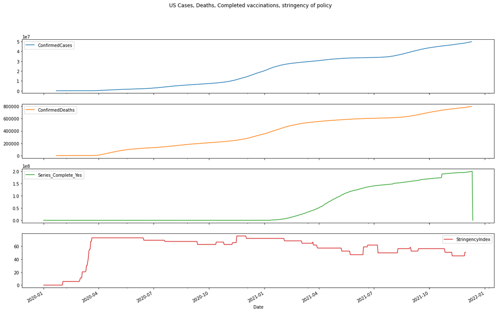

```python
data_us_states['US'].plot(subplots=True,y=['ConfirmedCases','ConfirmedDeaths','Series_Complete_Yes','StringencyIndex'],
    title='US Cases, Deaths, Completed vaccinations, stringency of policy', figsize=(20,12))
US_Total = data_us_states['US']
```

#### 3.2 plot the data in a general scale of US using animation

After ploting out the four values, I can see some important time series that the policies are chaning. The first one is between March and April, 2020. We can see that the stringency is suddently increasing. The second one is between July and November. Although the number of cases and deaths was steadily increasing, the strigency of policies was decreasing. As a result, it was a incredible increase around December 2020. The third one is between February and July 2021. As the number of vaccinations increasing, the cases and deaths grew slower and the stringency of policies was decreasing. The fourth one is around December 2021. There is a increasing trend of the cases and stringency of policies.

Then, I want to take a closer look at the data to see what is the more exact date of the change. What is the related information in the timeline at those periods. I plot the four lines animation to show the change of date directly. I will use [Pandas Alive](https://jackmckew.github.io/pandas_alive/README.html) to show the animation.

```python
US_Total = US_Total[['ConfirmedCases','ConfirmedDeaths','Series_Complete_Yes','StringencyIndex']]
US_Total.dropna(inplace=True)
US_Total.sort_index(inplace=True)
plots = []
for i in US_Total:
    plots.append(US_Total[i].plot_animated(kind='line',steps_per_period=1,period_length=10,period_fmt='%Y-%m-%d',fixed_max=True))
figs = plt.Figure()
figs.set_dpi(144)
gs = figs.add_gridspec(len(plots),1,hspace=0.5)
f1_ax = []
for i in range(len(plots)):
    f1_ax.append(figs.add_subplot(gs[i,0]))
    plots[i].ax = f1_ax[i]
pandas_alive.animate_multiple_plots(filename='US_line.mp4',plots=plots, custom_fig=figs, enable_progress_bar=True)
```

```
Generating LineChart, plotting ['ConfirmedCases']
Generating LineChart, plotting ['ConfirmedDeaths']
Generating LineChart, plotting ['Series_Complete_Yes']
Generating LineChart, plotting ['StringencyIndex']
```

```python
from IPython.display import Video
Video("US_line.mp4")
```

[video not shown]

Through the animation, I can the the first important date is around March 10. Looking it up in the timeline data, we can see on March 10 WHO announced that COVID-10 a pandemic. On March 13 "President Donald J. Trump declares a nationwide emergency". On March 15 US states started shuting down. As a result, the stringency increased rapidly. During the second period, as the presidential election was pushing forward, Trump was tested positive on Oct 2,2020. Soon enough, Trump anounced that he was recovered. So the stringency decreased a little bit. On Nov 3 the election occured. We can observe the tangent line of the confirmed cases changed rapidly around that time, which means the rate of cases increased rapidly. Right after the election, the stringency was increading again. In the third period, vaccines for COVID-19 came out. As number of vaccination was increasing, the rate of cases and deaths decreased then the stringency of the policies decreased. In the fourth period, the Omicron mutation was detected. There is an increasing trend of the cases and the stringency of the policies.

At this point, I would like to make an assumption that the stringency of policies is related to the increasing rate of cased and the coverage of vaccination. The government tends to control the rate of cases. This is a general assumption. Then I will visualize the data of most states to further explore the relationship between the policies and the COVID-19.

#### 3.3 plot the data across the US states using bar chart and geo map in animation

For the next step, I try ploting all the data for every state in the US animatively. To do this I needs several dataFrames, which have states as columns and date as index. Each dataFrame represents an element (ConfirmedCases, ConfirmedDeaths etc.).

```python
Series_df = pd.DataFrame(index=US_Total.index)
US_Cases_df = pd.DataFrame(index=US_Total.index)
US_Deaths_df = pd.DataFrame(index=US_Total.index)
US_Stringency_df = pd.DataFrame(index=US_Total.index)
for state, df in US_data[['State','ConfirmedCases','ConfirmedDeaths','Series_Complete_Yes','StringencyIndex']].groupby('State'):
    df.sort_index(inplace=True)
    if state != 'US':
        df.fillna(0,inplace=True)
        Series_df[state] = df['Series_Complete_Yes']
        US_Cases_df[state] = df['ConfirmedCases']
        US_Deaths_df[state] = df['ConfirmedDeaths']
        US_Stringency_df[state] = df['StringencyIndex']

series_chart = Series_df.plot_animated(steps_per_period=1,period_length=15,period_fmt='%Y-%m-%d',dpi=144,n_visible=25,figsize=(15,7.5),orientation='v',writer='ffmpeg',bar_label_size=5)
cases_chart = US_Cases_df.plot_animated(steps_per_period=1,period_length=15,period_fmt='%Y-%m-%d',dpi=300,n_visible=25,figsize=(20,10),orientation='v',writer='ffmpeg',bar_label_size=5)
deaths_chart = US_Deaths_df.plot_animated(steps_per_period=1,period_length=15,period_fmt='%Y-%m-%d',dpi=144,n_visible=25,figsize=(15,7.5),orientation='v',writer='ffmpeg',bar_label_size=5)
strigency_chart = US_Stringency_df.plot_animated(steps_per_period=1,period_length=15,period_fmt='%Y-%m-%d',dpi=144,figsize=(15,7.5),n_visible=30,orientation='v',bar_label_size=5)
```

```
Generating BarChartRace, plotting ['AK', 'AL', 'AR', 'AS', 'AZ', 'CA', 'CO', 'CT', 'DC', 'DE', 'FL', 'FM', 'GA', 'GU', 'HI', 'IA', 'ID', 'IL', 'IN', 'KS', 'KY', 'LA', 'MA', 'MD', 'ME', 'MH', 'MI', 'MN', 'MO', 'MP', 'MS', 'MT', 'NC', 'ND', 'NE', 'NH', 'NJ', 'NM', 'NV', 'NY', 'OH', 'OK', 'OR', 'PA', '…
Generating BarChartRace, plotting ['AK', 'AL', 'AR', 'AS', 'AZ', 'CA', 'CO', 'CT', 'DC', 'DE', 'FL', 'FM', 'GA', 'GU', 'HI', 'IA', 'ID', 'IL', 'IN', 'KS', 'KY', 'LA', 'MA', 'MD', 'ME', 'MH', 'MI', 'MN', 'MO', 'MP', 'MS', 'MT', 'NC', 'ND', 'NE', 'NH', 'NJ', 'NM', 'NV', 'NY', 'OH', 'OK', 'OR', 'PA', '…
Generating BarChartRace, plotting ['AK', 'AL', 'AR', 'AS', 'AZ', 'CA', 'CO', 'CT', 'DC', 'DE', 'FL', 'FM', 'GA', 'GU', 'HI', 'IA', 'ID', 'IL', 'IN', 'KS', 'KY', 'LA', 'MA', 'MD', 'ME', 'MH', 'MI', 'MN', 'MO', 'MP', 'MS', 'MT', 'NC', 'ND', 'NE', 'NH', 'NJ', 'NM', 'NV', 'NY', 'OH', 'OK', 'OR', 'PA', '…
Generating BarChartRace, plotting ['AK', 'AL', 'AR', 'AS', 'AZ', 'CA', 'CO', 'CT', 'DC', 'DE', 'FL', 'FM', 'GA', 'GU', 'HI', 'IA', 'ID', 'IL', 'IN', 'KS', 'KY', 'LA', 'MA', 'MD', 'ME', 'MH', 'MI', 'MN', 'MO', 'MP', 'MS', 'MT', 'NC', 'ND', 'NE', 'NH', 'NJ', 'NM', 'NV', 'NY', 'OH', 'OK', 'OR', 'PA', '…
```

After doing the above steps, I can plot multiple bar charts. Then I want to plot them together with geometry information. So I downloaded the shapefile of the US from [US Census](https://www2.census.gov/geo/tiger/GENZ2018/shp/cb_2018_us_state_500k.zip). I also use [geopandas](https://geopandas.org/en/stable/index.html) to read the shapefile. Then I used [EPSG:3081](https://epsg.io/3081) to convert the coordinate system. I removed the states GU MP NV AS HI, since they are too small to be shown.

```python
states_map = geopandas.read_file('cb_2018_us_state_500k.shp')
states_map = states_map.to_crs(epsg=3081)
# remove GU MP NV AS HI
states_map = states_map[states_map.STUSPS != 'GU']
states_map = states_map[states_map.STUSPS != 'MP']
states_map = states_map[states_map.STUSPS != 'NV']
states_map = states_map[states_map.STUSPS != 'AS']
states_map = states_map[states_map.STUSPS != 'HI']
states_map.set_index('STUSPS',inplace=True)
```

Before plotting, I need to convert the DataFrames into GeoDataFrames embeded geometry information. The first step is transposing the dataFrames to have states as index and date as columns. Then I convert geometry information into a dictionary. Using the dictionary, I assign the geometry information to the states. Then I convert the GeoDataFrames into GeoDataFrames. I want to plot the data in a $2\times 2$ spacegrid. the code is as follows:

```python
US_cases_gdf = US_Cases_df.T
US_Deaths_gdf = US_Deaths_df.T
US_Stringency_gdf = US_Stringency_df.T
US_series_gdf = Series_df.T
dict = states_map['geometry'].to_dict()
US_cases_gdf['geometry'] = US_cases_gdf.index.map(dict)
US_Deaths_gdf['geometry'] = US_Deaths_gdf.index.map(dict)
US_Stringency_gdf['geometry'] = US_Stringency_gdf.index.map(dict)
US_series_gdf['geometry'] = US_series_gdf.index.map(dict)
US_cases_gdf = US_cases_gdf[US_cases_gdf['geometry'].notna()]
US_Deaths_gdf = US_Deaths_gdf[US_Deaths_gdf['geometry'].notna()]
US_Stringency_gdf = US_Stringency_gdf[US_Stringency_gdf['geometry'].notna()]
US_series_gdf = US_series_gdf[US_series_gdf['geometry'].notna()]
US_cases_gdf = geopandas.GeoDataFrame(US_cases_gdf,crs=states_map.crs,geometry=US_cases_gdf['geometry'])
US_Deaths_gdf = geopandas.GeoDataFrame(US_Deaths_gdf,crs=states_map.crs,geometry=US_Deaths_gdf['geometry'])
US_Stringency_gdf = geopandas.GeoDataFrame(US_Stringency_gdf,crs=states_map.crs,geometry=US_Stringency_gdf['geometry'])
US_series_gdf = geopandas.GeoDataFrame(US_series_gdf,crs=states_map.crs,geometry=US_series_gdf['geometry'])
US_cases_gdf.sort_index(inplace=True)
US_Deaths_gdf.sort_index(inplace=True)
US_Stringency_gdf.sort_index(inplace=True)
US_series_gdf.sort_index(inplace=True)
geo_stri = US_Stringency_gdf.plot_animated(steps_per_period=1,period_length=15,period_fmt='%Y-%m-%d',dpi=144,cmap='Oranges', fixed_max=False,title='strigency',figsize=(20,12),writer='ffmpeg')
figs = plt.Figure()
figs.set_dpi(200)
figs.set_size_inches(10,5.625)
gs = figs.add_gridspec(2,2)
f2_ax1 = figs.add_subplot(gs[0,0])
cases_chart.ax = f2_ax1
cases_chart.ax.set_title('Confirmed Cases')
f2_ax2 = figs.add_subplot(gs[0,1])
deaths_chart.ax = f2_ax2
deaths_chart.ax.set_title('Confirmed Deaths')
f2_ax3 = figs.add_subplot(gs[1,0])
series_chart.ax = f2_ax3
series_chart.ax.set_title('Series Complete')
f2_ax4 = figs.add_subplot(gs[1,1])
f2_ax4.set_title('strigency')
geo_stri.ax = f2_ax4
plots = [cases_chart,deaths_chart,series_chart,geo_stri]
pandas_alive.animate_multiple_plots(filename='All_states_bar.mp4',plots=plots, custom_fig=figs,adjust_subplot_hspace=.1,adjust_subplot_wspace=.1)
```

| Confirmed Cases | Confirmed Deaths |
| --- | --- |
| Completed Vaccinations | Stringency of States |

In the plot of Stringency of States, the color represents the value. Deeper the color, the higher the stringency.

```python
Video('All_states_bar.mp4')
```

[video not shown]

From this animation, I can further confirmed my assumption that the stringency of policies is related to the increasing rate of cased and the number of vaccinations. I believe it could also be correct for most states. To make a further observation, I plot the four values separately using geo map.

```python
US_cases_gdf.plot_animated(filename='geoCases.mp4',steps_per_period=1,period_length=10,period_fmt='%Y-%m-%d',cmap="Reds",dpi=144, fixed_max=True)
US_Deaths_gdf.plot_animated(filename='geoDeaths.mp4',steps_per_period=1,period_length=10,period_fmt='%Y-%m-%d',cmap="Reds",dpi=144, fixed_max=True)
US_Stringency_gdf.plot_animated(filename='geoStringency.mp4',steps_per_period=1,period_length=10,period_fmt='%Y-%m-%d',cmap="Reds",dpi=144, fixed_max=True)
US_series_gdf.plot_animated(filename='geoSeries.mp4',steps_per_period=1,period_length=10,period_fmt='%Y-%m-%d',cmap="Reds",dpi=144, fixed_max=True)
```

This is how the cases progress in the US.

```python
Video('geoCases.mp4')
```

[video not shown]

This is how the deaths progress in the US.

```python
Video('geoDeaths.mp4')
```

[video not shown]

This is how the stringency changes in the US.

```python
Video('geoStringency.mp4')
```

[video not shown]

This is the animation of the number of completed vaccinations in the US.

```python
Video('geoSeries.mp4')
```

[video not shown]

## 4 Numerical Analysis

#### 4.1 basic observation of numerical analysis

To confirm my assumption that the stringency of policies is related to the increasing rate of cases and the number of vaccinations, I will use the following steps to do this:

1. define a patition $P$, which divides the data into $n$ parts.
2. $dates = date_n-date_0$
3. rate of cases or rate of deaths in $P$ can be defined as the rate of average of the data in the $P$ part. For instance, $R_{Ci} = \frac{{C_i}-{C{i-1}}}{Date_i-Date_{i-1}}, i\ge 1, i < n$
4. In patition $P$, the strigency can be defined as the average each patition $[i-1,i]$. $S_i = \frac{\sum\limits_{j=date_{i-1}}^{date_i}S[j]}{date_i-date_{i-1}}$

Then, I want to calculate the correlation of different $n$

```python
stri_dict = {}
cases_dict = {}
deaths_dict = {}
vacc_dict = {}
states = []
AnalyzeData = US_data[['State','ConfirmedCases','ConfirmedDeaths','Series_Complete_Yes','StringencyIndex']].dropna()
AnalyzeData.sort_index(inplace=True)
for state, df in AnalyzeData.groupby('State'):
    states.append(state)
    stri_dict[state] = df['StringencyIndex'].to_numpy()
    cases_dict[state] = df['ConfirmedCases'].to_numpy()
    deaths_dict[state] = df['ConfirmedDeaths'].to_numpy()
    vacc_dict[state] = df['Series_Complete_Yes'].to_numpy()

for n in [50,100,200,300]:
    RC = [(i[-1]-i[0])/len(i) for i in np.array_split(cases_dict['US'],n)]
    RD = [(i[-1]-i[0])/len(i) for i in np.array_split(deaths_dict['US'],n)]
    S = [np.average(i) for i in np.array_split(stri_dict['US'],n)]
    V = [np.average(i) for i in np.array_split(vacc_dict['US'],n)]
    print(f'for n = {n} corref of RC and S is\n{np.corrcoef(RC,S)}\ncorref of RD and S is\n{np.corrcoef(RD,S)}\ncorref of V and S is\n{np.corrcoef(V,S)}\ncorref V and RD is\n{np.corrcoef(V,RD)}\ncorref V and RC is\n{np.corrcoef(V,RC)}')
```

```
for n = 50 corref of RC and S is
[[1.         0.37017264]
 [0.37017264 1.        ]]
corref of RD and S is
[[1.         0.55440357]
 [0.55440357 1.        ]]
corref of V and S is
[[ 1.        -0.2331852]
 [-0.2331852  1.       ]]
corref V and RD is
[[ 1.         -0.11035352]
 [-0.11035352  1.        ]]
corref V and RC is
[[1.        0.0815869]
 [0.0815869 1.       ]]
for n = 100 corref of RC and S is
[[1.         0.35530638]
 [0.35530638 1.        ]]
corref of RD and S is
[[1.         0.53684239]
 [0.53684239 1.        ]]
corref of V and S is
[[ 1.         -0.23429142]
 [-0.23429142  1.        ]]
corref V and RD is
[[ 1.         -0.08309671]
 [-0.08309671  1.        ]]
corref V and RC is
[[1.         0.10021116]
 [0.10021116 1.        ]]
for n = 200 corref of RC and S is
[[1.         0.37082293]
 [0.37082293 1.        ]]
corref of RD and S is
[[1.         0.51513346]
 [0.51513346 1.        ]]
corref of V and S is
[[ 1.         -0.26498097]
 [-0.26498097  1.        ]]
corref V and RD is
[[ 1.       -0.171364]
 [-0.171364  1.      ]]
corref V and RC is
[[1.         0.01849778]
 [0.01849778 1.        ]]
for n = 300 corref of RC and S is
[[1.         0.36350682]
 [0.36350682 1.        ]]
corref of RD and S is
[[1.         0.50670336]
 [0.50670336 1.        ]]
corref of V and S is
[[ 1.         -0.29366068]
 [-0.29366068  1.        ]]
corref V and RD is
[[ 1.         -0.20377077]
 [-0.20377077  1.        ]]
corref V and RC is
[[ 1.         -0.00989673]
 [-0.00989673  1.        ]]
```

#### 4.2 further observation of numerical analysis

For further analysis, I want to make two kind of regression models to fit the data. One is linear. The other is non linear.

1. define a function of stringency in terms of rate of cases, rate of deaths, and number of vaccination. $S = c\cdot X, X=\begin{pmatrix}{R_c \\ R_d \\ V}\end{pmatrix}$
2. define a function of rate of cases in terms of stringency and number of vaccination. $R_c = c\cdot X, X=\begin{pmatrix}{S \\ V}\end{pmatrix}$
3. for non linear regression, use SVR. or in math $Ac=y$. $A$ is a matrix.

Then I can calculate different models using different partition $P$, which means different $n$.

```python
from sklearn import linear_model
from sklearn.svm import SVR

reg_S_linear = {}
reg_Rc_linear = {}
reg_S_nonlinear = {}
reg_Rc_nonlinear = {}
for n in [100,200,300]:
    reg_S_linear[n] = linear_model.LinearRegression()
    reg_Rc_linear[n] = linear_model.LinearRegression()
    reg_S_nonlinear[n] = SVR(kernel='rbf')
    reg_Rc_nonlinear[n] = SVR(kernel='rbf')
    RC = [(i[-1]-i[0])/len(i) for i in np.array_split(cases_dict['US'],n)]
    RD = [(i[-1]-i[0])/len(i) for i in np.array_split(deaths_dict['US'],n)]
    S = [np.average(i) for i in np.array_split(stri_dict['US'],n)]
    V = [np.average(i) for i in np.array_split(vacc_dict['US'],n)]
    X1 = [[RC[i],RD[i],V[i]] for i in range(len(RC))]
    X2 = [[S[i],V[i]] for i in range(len(RC))]
    reg_S_linear[n].fit(X1,S)
    reg_S_nonlinear[n].fit(X1,S)
    reg_Rc_linear[n].fit(X2,RC)
    reg_Rc_nonlinear[n].fit(X2,RC)
```

Then I want to plot the results of the regression models and calculate the error, or say loss using $$Loss=\frac{1}{2}||\hat{y}-y||$$

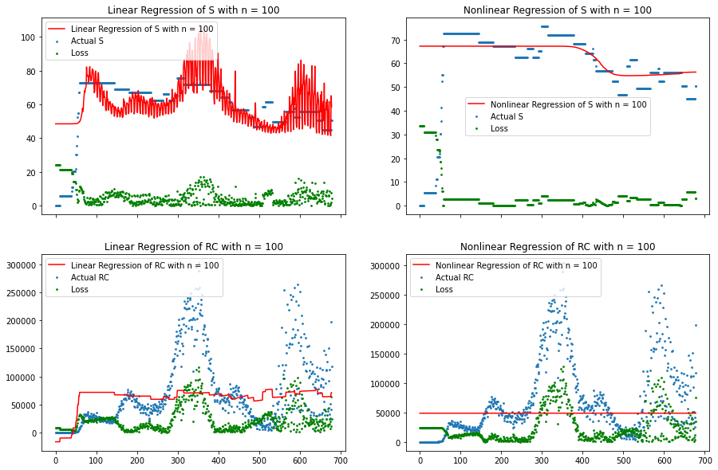

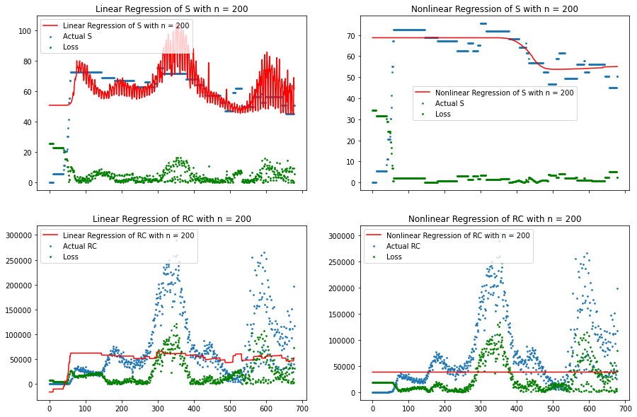

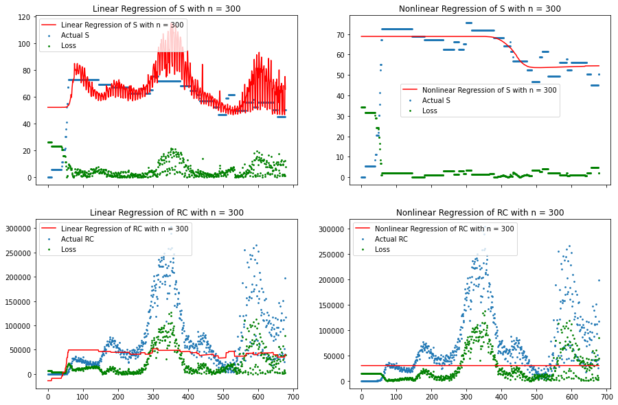

```python
def loss(x,y,reg):
    return abs(reg.predict(x) - y)/2
RC = [cases_dict['US'][i]-cases_dict['US'][i-1] for i in range(1,len(cases_dict['US']))]
RC.insert(0,0)
RD = [deaths_dict['US'][i]-deaths_dict['US'][i-1] for i in range(1,len(deaths_dict['US']))]
RD.insert(0,0)
S = stri_dict['US']
V = vacc_dict['US']
X1 = [[RC[i],RD[i],V[i]] for i in range(len(RC))]
X2 = [[S[i],V[i]] for i in range(len(RC))]
X = range(len(RC))
for n in reg_S_linear.keys():
    fig, axes = plt.subplots(2,2,figsize=(15,10),sharex=True)
    axes[0][0].plot(X,reg_S_linear[n].predict(X1),label=f'Linear Regression of S with n = {n}',color='red')
    axes[0][0].scatter(X,S,label='Actual S',s=3)
    axes[0][0].scatter(X,loss(X1,S,reg_S_linear[n]),label='Loss',color='green',s=3)
    axes[0][0].legend()
    axes[0][0].set_title(f'Linear Regression of S with n = {n}')

    axes[0][1].plot(X,reg_S_nonlinear[n].predict(X1),label=f'Nonlinear Regression of S with n = {n}',color='red')
    axes[0][1].scatter(X,S,label='Actual S',s=3)
    axes[0][1].scatter(X,loss(X1,S,reg_S_nonlinear[n]),label='Loss',color='green',s=3)
    axes[0][1].legend()
    axes[0][1].set_title(f'Nonlinear Regression of S with n = {n}')

    axes[1][0].plot(X,reg_Rc_linear[n].predict(X2),label=f'Linear Regression of RC with n = {n}',color='red')
    axes[1][0].scatter(X,RC,label='Actual RC',s=3)
    axes[1][0].scatter(X,loss(X2,RC,reg_Rc_linear[n]),label='Loss',color='green',s=3)
    axes[1][0].legend()
    axes[1][0].set_title(f'Linear Regression of RC with n = {n}')

    axes[1][1].plot(X,reg_Rc_nonlinear[n].predict(X2),label=f'Nonlinear Regression of RC with n = {n}',color='red')
    axes[1][1].scatter(X,RC,label='Actual RC',s=3)
    axes[1][1].scatter(X,loss(X2,RC,reg_Rc_nonlinear[n]),label='Loss',color='green',s=3)
    axes[1][1].legend()
    axes[1][1].set_title(f'Nonlinear Regression of RC with n = {n}')
```

## Conclusion and Future Work

So far I can conclude that the stringency in the US, without digging into each states, is driven by the rate of cases, rate of deaths, and number of completed vaccination.